# Text Analysis with R

Wouter van Atteveldt  
Glasgow Text Analysis, 2016-11-17

### Course Overview

10:30 - 12:00

- Recap: Frequency Based Analysis and the DTM
- Dictionary Analysis with AmCAT and R

13:30 - 15:00

- Simple Natural Language Processing
- Corpus Analysis and Visualization
- Topic Modeling and Visualization

15:15 - 17:00

- Sentiment Analysis with dictionaries
- Sentiment Analysis with proximity

## Frequency Based Analysis: The DTM

### Frequency Based Analysis

- Analysis based on word frequency only
  - “Bag of words” assumption
  - Ignore grammar, proximity, relations, …
- Main data: Document-term matrix (dtm)
- Can also use other features (dfm)
  - Bag of stems, lemmata, word pairs, …

### Creating a DTM

1. Text source
   - Text files
   - Data frames / vectors or text
   - External sources/APIs
2. Preprocessing
   - Stemming, lowercasing, lemmatizing
   - Collocations
3. Feature selection
   - Frequency
   - Stopwords

### Creating a DTM from text

```r
library(quanteda)
texts=c("This is a test", "They tested a test", "I found a test!")
dfm(texts)
```

```
Document-feature matrix of: 3 documents, 8 features (50% sparse).
3 x 8 sparse Matrix of class "dfmSparse"
       features
docs    this is a test they tested i found
  text1    1  1 1    1    0      0 0     0
  text2    0  0 1    1    1      1 0     0
  text3    0  0 1    1    0      0 1     1
```

### Preprocessing: stemming, stopword removal

```r
dfm(texts, stem=T, ignoredFeatures=stopwords("english"))
```

```
Document-feature matrix of: 3 documents, 2 features (33.3% sparse).
3 x 2 sparse Matrix of class "dfmSparse"
       features
docs    test found
  text1    1     0
  text2    2     0
  text3    1     1
```

### Preprocessing: collocations

```r
coll = collocations(texts)
head(coll)
```

```
   word1  word2 word3 count        G2
1:     a   test           3 14.045308
2:     i  found           1  7.050924
3:  they tested           1  7.050924
4:  this     is           1  7.050924
5: found      a           1  3.231839
6:    is      a           1  3.231839
```

### Preprocessing: collocations

```r
texts2 = phrasetotoken(texts, subset(coll, G2>10))
texts2
```

```
[1] "This is a_test"     "They tested a_test" "I found a_test!"
```

```r
dfm(texts2,  stem=T, ignoredFeatures=stopwords("english"))
```

```
Document-feature matrix of: 3 documents, 3 features (44.4% sparse).
3 x 3 sparse Matrix of class "dfmSparse"
       features
docs    a_test test found
  text1      1    0     0
  text2      1    1     0
  text3      1    0     1
```

### Feature selection

```r
dfm = dfm(texts2, stem=T)
dfm = trim(dfm, minDoc = 2)
dfm
```

```
Document-feature matrix of: 3 documents, 1 feature (0% sparse).
3 x 1 sparse Matrix of class "dfmSparse"
       features
docs    a_test
  text1      1
  text2      1
  text3      1
```

### More control: quanteda step-by-step

```r
tokens = tokenize(texts2, removePunct = T)
tokens = toLower(tokens)
tokens = wordstem(tokens, "english")
dfm = dfm(tokens)
dfm = selectFeatures(dfm, stopwords("english"), "remove")
dfm = trim(dfm, minCount = 1)
dfm
```

```
Document-feature matrix of: 3 documents, 3 features (44.4% sparse).
3 x 3 sparse Matrix of class "dfmSparse"
       features
docs    a_test test found
  text1      1    0     0
  text2      1    1     0
  text3      1    0     1
```

### (De-)Motivational example: Dutch stemming

```r
texts = c("De kippen eten", "De kip heeft gegeten")
dfm(texts, language="dutch", stem=T, ignoredFeatures=stopwords("dutch"))
```

```
Document-feature matrix of: 2 documents, 4 features (50% sparse).
2 x 4 sparse Matrix of class "dfmSparse"
       features
docs    kipp eten kip geget
  text1    1    1   0     0
  text2    0    0   1     1
```

(We will cover lemmatizing and POS-tagging this afternoon!)

## Dictionary-based analysis

### Dictionary-based analysis

- Use list of keywords to define a concept
- (words, wildcards, boolean combinations, phrases, etc.)
- Measure (co-)occurrence of these concepts

Advantages of dictionaries?

- Easy to explain
- Easy to use
- Control over operationalization

### AmCAT

- Free and Open Source text analysis infrastructure
- Easy corpus management, keyword queries
- Integrates with R / quanteda
- Run your own server or use ours (amcat.nl)

## AmCAT demo

### Connecting to AmCAT from R

```r
devtools::install_github("amcat/amcat-r")
library(amcatr)
amcat.save.password("https://amcat.nl", username="...",
                    password="...")
```

```r
conn = amcat.connect("https://amcat.nl")
meta = amcat.articles(conn, project=1235, articleset=32114, dateparts = T)
table(meta$medium)
```

```
      The New York Times The New York Times Blogs                USA TODAY
                    9551                     1660                     1993
```

```r
saveRDS(meta, "meta.rds")
```

### Running AmCAT queries in R

```r
a = amcat.aggregate(conn, sets=32139, queries = c("trump", "clinton"), axis1 = "week")
head(a)
```

```
  count       week query
1    14 2015-12-28 trump
2    51 2016-01-04 trump
3    65 2016-01-11 trump
4    66 2016-01-18 trump
5    92 2016-01-25 trump
6    94 2016-02-01 trump
```

### Running AmCAT queries in R

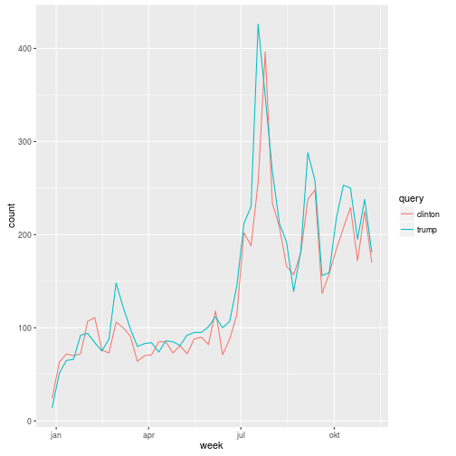

```r
library(ggplot2)
ggplot(data=a, mapping=aes(x=week, y=count, color=query)) + geom_line()
```

### Getting AmCAT data into R

```r
h = amcat.hits(conn, sets=32142,
               queries=c("trump", "clinton"))
meta = amcat.articles(conn, project=1235,
                      articleset=32142)
h = merge(meta, h)
head(h)
```

```
         id       date             medium count   query
1 162317450 2016-03-01 The New York Times     1 clinton
2 162317731 2016-02-02 The New York Times     7   trump
3 162317731 2016-02-02 The New York Times     4 clinton
4 162317809 2016-01-25 The New York Times     1   trump
5 162317820 2016-01-24 The New York Times     1 clinton
6 162317856 2016-01-18 The New York Times     1   trump
```

### Getting AmCAT texts into R

```r
articles = amcat.articles(conn, project=1235,
  articleset=32142, dateparts=T,
  columns=c("date", "headline", "text"))
articles$text[1]
```

```
[1] "Every Friday, pop critics for The New York Times weigh in on the week's most\nnotable new songs and videos -- and anything else that strikes them as\nintriguing -- in the Playlist. You can listen to this playlist on Spotify here.\nLike this format? Let us know at theplaylist@nytimes.com\n\nThun…
```

### AmCAT and quanteda

```r
d = dfm(articles$text, stem=T,
        ignoredFeatures=stopwords("english"))
d = trim(d, minDoc=10)
d = weight(d, "tfidf")
topfeatures(d)
```

```
       mr       p.m    street     trump       mrs   theater      said
1686.3507 1512.2909 1208.5387 1067.8813 1064.3875  998.5898  970.0412
   museum       art   clinton
 942.1813  852.4824  788.3125
```

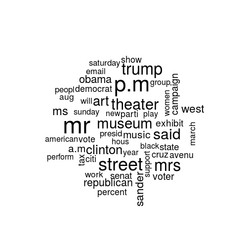

```r
plot(d, max.words = 50, scale = c(4, 0.5))
```

### AmCAT and quantea (2)

```r
c = quanteda.corpus(conn, project=1235, articleset=32142, dateparts=T)
d = dfm(c, ignoredFeatures=stopwords("english"))
head(d)
```

```
Document-feature matrix of: 1,000 documents, 41,920 features (99.2% sparse).
(showing first 6 documents and first 6 features)
           features
docs        every friday pop critics new york
  171933722     1      2   4       1   6    1
  171933835     0      0   0       0   2    1
  171937938     0      0   0       0   1    1
  171937818     0      0   0       0   0    0
  171935088     0      0   0       0  12   10
  171935925     1      0   0       0   5    1
```

### Dictionares within R

```r
issues = list(economy=c("econ*", "inflation"), immigration=c("immigr*", "mexican*"))
d2 = applyDictionary(d, issues, exclusive=T)
head(d2)
```

```
Document-feature matrix of: 1,000 documents, 2 features (0% sparse).
(showing first 6 documents and first 2 features)
           features
docs        economy immigration
  171933722       0           0
  171933835       1           0
  171937938       0           0
  171937818       0           0
  171935088       0           0
  171935925       1          17
```

### Dictionares within R

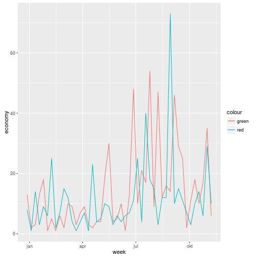

```r
d2 = cbind(docvars(c), as.matrix(d2))
a = aggregate(d2[names(issues)], d2["week"], sum)
ggplot(a, aes(x=week)) +
  geom_line(aes(y = economy, color="green"))  +
  geom_line(aes(y = immigration, color="red"))
```

### Where to get dictionaries?

- Create your own
- Create from corpora (next session)
- Replication materials
- wordstat, LIWC, …

### Hands-on session I

- Why did Trump win the (primary) election?
- Operationalize a variable using search strings
  - candidates, issues, emotion, populism, …
  - download or create word list
- Plot variable over time / co-occurring with either candidate
- Use AmCAT GUI, AmCAT R, quanteda, …